# Table of Content

## 3.4 What do we learn from above histograms?

- age: Clients mostly concentrated around the 20 to 60 value range, several outliers at the end.
- Pdays: records how many days have been since the last contact of this client, 999 indicates the customer was never contacted before;More than 95% of customers were never contacted before;
- Previous: indicates how many times the customer was contacted in previous campaign; More than 85% of customers were contacted zero times in previous campagin;
- Duration and campaign are heavily skewed and this might due to the presence of outliers.
- emp.var.rate, cons.price.idx, cons.conf.idx, euribor3m, nr.employed: no obvious pattern found.

## 3.5 Boxplots for Age, Duration and Campaign

- This is for further detect the outliers for above three features

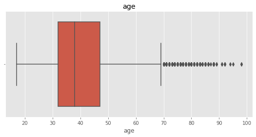

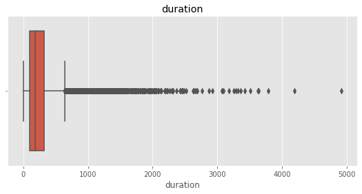

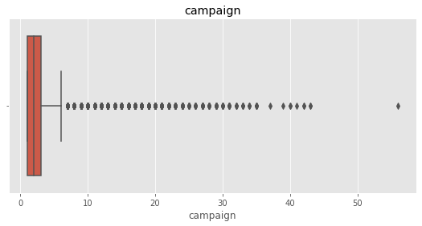

```python
#boxplot for age, duration and campagin:
plt.style.use("ggplot")
for column in ["age", "duration", "campaign"]:
    plt.figure(figsize=(20,4))
    plt.subplot(121)
    sns.boxplot(df[column])
    plt.title(column)
#Note that we must drop 'duration' column for the final modeling,
#thus we don't need to treat the outliers
```

- There are indeed outliers on the right tail of distributions of above three features, we will deal with it later at pre-processing stage of data set.

## 3.6 Bivarate data analysis

```python
#defining bivarate plot:
def plot_bivarate(col):
    plt.figure()
    x1 = df.groupby(col)[col].count()
    x2 = df.groupby(col).y.mean()
    ax1 = x1.plot(kind = 'bar',rot=45,
                  color="b", grid = 'true',figsize=(8,6))
    ax1.set_xlabel(col,fontsize=16)
    ax1.set_ylabel('# of clients',fontsize=16)
    ax1.xaxis.set_tick_params(labelsize=10)
    ax1.yaxis.set_tick_params(labelsize=10)

    ax2 = ax1.twinx()
    x2. plot(kind = 'line', ax = ax2, color = 'orange', lw = 3)
    ax2.set_ylabel('% Conversion Rate',fontsize=16)
    ax2.set_ylim(0, 1)
    ax2.set_xticklabels(ax1.get_xticklabels(),
                          rotation=45,
                          horizontalalignment='right')
```

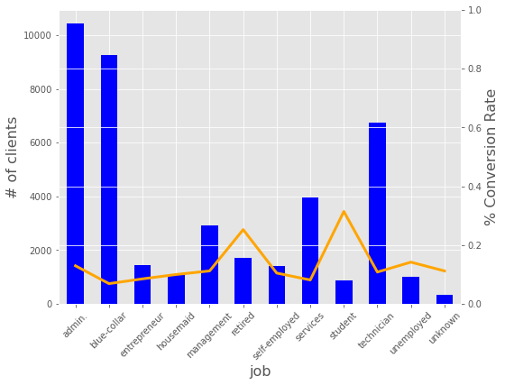

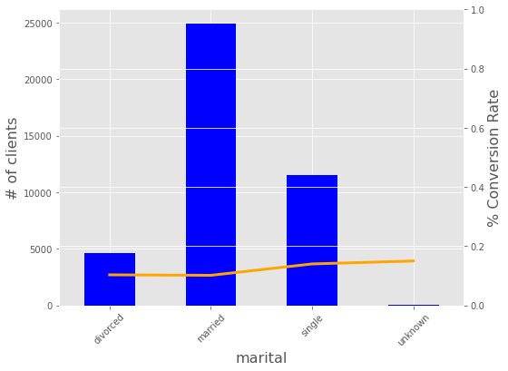

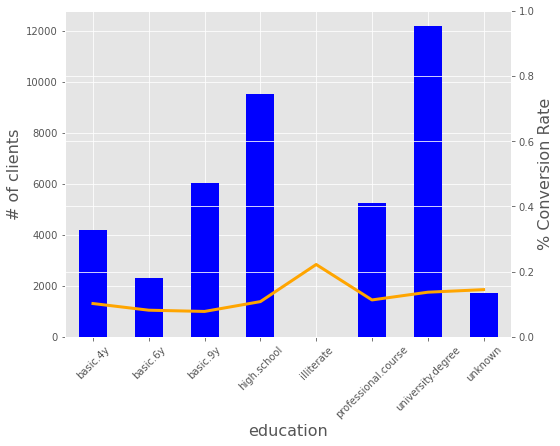

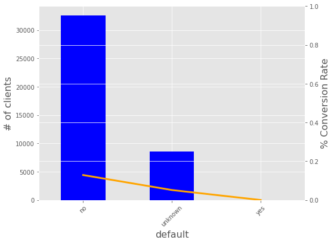

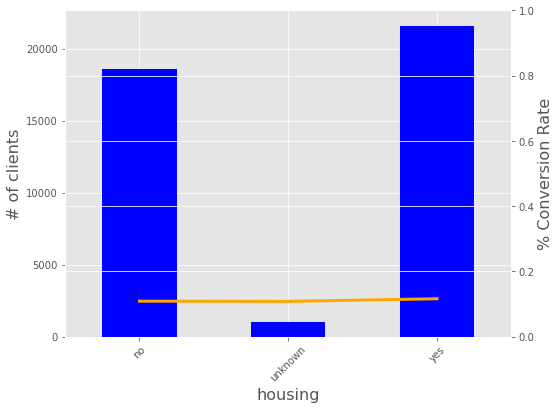

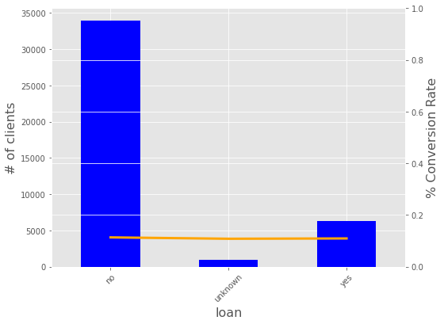

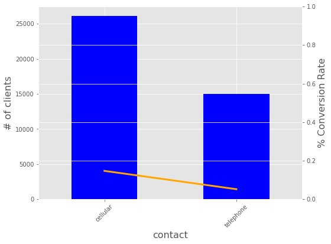

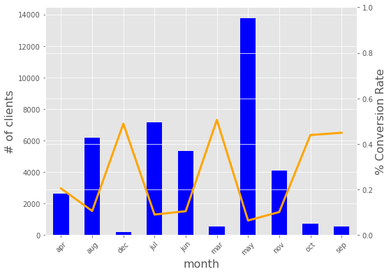

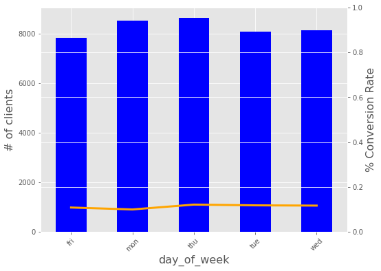

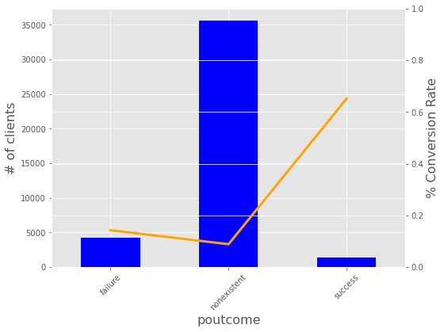

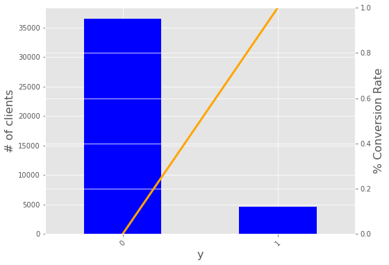

```python
#Bivariate analysis for categorical variables:
for col in non_numeric_cols:
    plot_bivarate(col)
```

[output not shown]

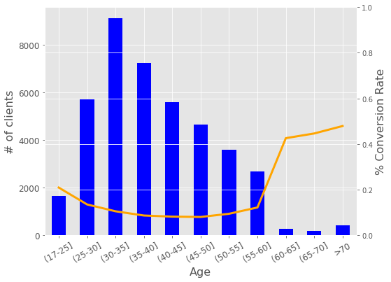

```python
#Bivariate plot for variable "age":
plt.figure()
x1 = out.value_counts(sort=False)
x2 = df.groupby(out).y.mean()
ax1 = x1.plot.bar(rot=30, color="b", grid = 'true',figsize=(8,6))
ax1.set_xticklabels(['(17-25]','(25-30]','(30-35]','(35-40]','(40-45]','(45-50]',
                            '(50-55]','(55-60]','(60-65]','(65-70]','>70'])
ax1.set_xlabel('Age',fontsize=16)
ax1.set_ylabel('# of clients',fontsize=16)
ax1.xaxis.set_tick_params(labelsize=12)
ax1.yaxis.set_tick_params(labelsize=12)

ax2 = ax1.twinx()
x2. plot(kind = 'line', ax = ax2, color = 'orange', lw = 3)
ax2.set_ylabel('% Conversion Rate',fontsize=16)
ax2.set_ylim(0, 1)
ax2.set_xticklabels(ax1.get_xticklabels(),
                          rotation=45,
                          horizontalalignment='right')
```

# 4. Data Preprocessing

- Split data into train and test;
- Handle data Multicollinearity;
- Deal with Outliers;
- One hot encoding/dummy variables--turn categorical variables into numerical variable;
- Variable Selection-dimension reduction;
- Balance the dataset (SMOTE)

## 4.1 Split data into train and test

```python
##################Correlation Matrix##########################
# Use the correlation matrix to decide what to do next:
corr = df.corr()
corr.style.background_gradient(cmap='PuBu')
```

|  | age | duration | campaign | pdays | previous | emp.var.rate | cons.price.idx | cons.conf.idx | euribor3m | nr.employed | y | pdays_in |
| --- | --- | --- | --- | --- | --- | --- | --- | --- | --- | --- | --- | --- |
| age | 1.000000 | -0.000808 | 0.004622 | -0.034381 | 0.024379 | -0.000242 | 0.001009 | 0.129075 | 0.010852 | -0.017607 | 0.030381 | -0.002766 |
| duration | -0.000808 | 1.000000 | -0.071765 | -0.047556 | 0.020600 | -0.027941 | 0.005303 | -0.008126 | -0.032861 | -0.044672 | 0.405297 | -0.016591 |
| campaign | 0.004622 | -0.071765 | 1.000000 | 0.052606 | -0.079182 | 0.150786 | 0.127826 | -0.013657 | 0.135169 | 0.144129 | -0.066361 | -0.067441 |
| pdays | -0.034381 | -0.047556 | 0.052606 | 1.000000 | -0.587508 | 0.271063 | 0.078920 | -0.091374 | 0.296946 | 0.372659 | -0.324948 | 0.065081 |
| previous | 0.024379 | 0.020600 | -0.079182 | -0.587508 | 1.000000 | -0.420587 | -0.203197 | -0.050929 | -0.454571 | -0.501411 | 0.230202 | 0.637887 |
| emp.var.rate | -0.000242 | -0.027941 | 0.150786 | 0.271063 | -0.420587 | 1.000000 | 0.775293 | 0.196257 | 0.972244 | 0.906949 | -0.298289 | -0.371284 |
| cons.price.idx | 0.001009 | 0.005303 | 0.127826 | 0.078920 | -0.203197 | 0.775293 | 1.000000 | 0.059170 | 0.688180 | 0.521945 | -0.136134 | -0.299250 |
| cons.conf.idx | 0.129075 | -0.008126 | -0.013657 | -0.091374 | -0.050929 | 0.196257 | 0.059170 | 1.000000 | 0.277864 | 0.100679 | 0.054802 | -0.171587 |
| euribor3m | 0.010852 | -0.032861 | 0.135169 | 0.296946 | -0.454571 | 0.972244 | 0.688180 | 0.277864 | 1.000000 | 0.945146 | -0.307740 | -0.373171 |
| nr.employed | -0.017607 | -0.044672 | 0.144129 | 0.372659 | -0.501411 | 0.906949 | 0.521945 | 0.100679 | 0.945146 | 1.000000 | -0.354669 | -0.330899 |
| y | 0.030381 | 0.405297 | -0.066361 | -0.324948 | 0.230202 | -0.298289 | -0.136134 | 0.054802 | -0.307740 | -0.354669 | 1.000000 | 0.017670 |
| pdays_in | -0.002766 | -0.016591 | -0.067441 | 0.065081 | 0.637887 | -0.371284 | -0.299250 | -0.171587 | -0.373171 | -0.330899 | 0.017670 | 1.000000 |

```python
#Remove "duration" column:
df = df.drop(columns=['duration'], axis = 1)
```

```python
# Split the data into X and y
X = df.drop("y",axis=1)
y = df["y"]

## Split the data into trainx, testx, trainy, testy with test_size = 0.30
X_train, X_test, y_train, y_test = train_test_split(X, y, test_size=0.30, random_state=0)
print(X_train.shape)
print(X_test.shape)
print(y_train.shape)
print(y_test.shape)
```

```
(28823, 20)
(12353, 20)
(28823,)
(12353,)
```

```python
#check the distribution of y_train, y_test to verify the split results:
y_train.value_counts()
y_test.value_counts() #still imbalanced on response variable, good!
```

```
0    10919
1     1434
Name: y, dtype: int64
```

## 4.2 Handle data Multicollinearity

- Calculate VIF and remove features based on the results

```python
#Handle data Multicollinearity:

# compute the vif for all given features
def compute_vif(considered_features):

    X = X_train[considered_features]
    # the calculation of variance inflation requires a constant
    X['intercept'] = 1

    # create dataframe to store vif values
    vif = pd.DataFrame()
    vif["Variable"] = X.columns
    vif["VIF"] = [variance_inflation_factor(X.values, i) for i in range(X.shape[1])]
    vif = vif[vif['Variable']!='intercept']
    return vif

# features to consider removing
considered_features = ['emp.var.rate', 'cons.price.idx', 'euribor3m', 'nr.employed']


# compute vif
compute_vif(considered_features).sort_values('VIF', ascending=False)
```

|  | Variable | VIF |
| --- | --- | --- |
| 0 | emp.var.rate | 32.831380 |
| 2 | euribor3m | 31.189665 |
| 3 | nr.employed | 14.359457 |
| 1 | cons.price.idx | 4.720722 |

```python
# compute vif values after removing a feature
considered_features.remove('emp.var.rate')
compute_vif(considered_features).sort_values('VIF', ascending=False)
```

|  | Variable | VIF |
| --- | --- | --- |
| 1 | euribor3m | 18.329185 |
| 2 | nr.employed | 13.230811 |
| 0 | cons.price.idx | 2.702843 |

```python
# compute vif values after removing one more feature
considered_features.remove('euribor3m')
compute_vif(considered_features).sort_values('VIF', ascending=False)

#Now that the variance inflation factors are all within the acceptable range, the derived model will be more likely to yield statistically significant results.
#Conclusion: we need to drop two features: emp.var.rate and euribor3m before building the models;
```

|  | Variable | VIF |
| --- | --- | --- |
| 0 | cons.price.idx | 1.38073 |
| 1 | nr.employed | 1.38073 |

```python
# remove two features on both train and test data set:
X_train = pd.DataFrame(X_train.drop(columns=['emp.var.rate','euribor3m'], axis = 1))
print(X_train.shape)
X_test = pd.DataFrame(X_test.drop(columns=['emp.var.rate','euribor3m'], axis = 1))
print(X_test.shape)
```

```
(28823, 18)
(12353, 18)
```